# Unit 6 | Assignment - What's the Weather Like?

#### Background

Whether financial, political, or social -- data's true power lies in its ability to answer questions definitively. So let's take what you've learned about Python requests, APIs, and JSON traversals to answer a fundamental question: "What's the weather like as we approach the equator?"

Now, we know what you may be thinking: "Duh. It gets hotter..."

But, if pressed, how would you prove it?

#### WeatherPy

In this example, you'll be creating a Python script to visualize the weather of 500+ cities across the world of varying distance from the equator. To accomplish this, you'll be utilizing a simple Python library, the OpenWeatherMap API, and a little common sense to create a representative model of weather across world cities.

Your objective is to build a series of scatter plots to showcase the following relationships:

- Temperature (F) vs. Latitude
- Humidity (%) vs. Latitude
- Cloudiness (%) vs. Latitude
- Wind Speed (mph) vs. Latitude

#### Initial Setup:

- Import Dependencies
- Bring in url and save to a variable

```python
#Dependencies
import openweathermapy.core as owm
from citipy import citipy
import random
import requests
import pandas as pd
import numpy as np
import matplotlib.pyplot as plt
import matplotlib
import seaborn as sns

# Bring in API Key from https://openweathermap.org/
from config import api_key
```

```python
#Generate random cities

# Set Latitude & Longitude to randomly pick coordinates
# We want to have some from each region.
lat_zone = np.arange(-90,90,15)
lon_zone = np.arange(-200,200,15)

#Create a dataframe to hold the random cities
cities_df = pd.DataFrame()

#Add colums to dataframe
cities_df["Latitude"] = ""
cities_df["Longitude"] = ""

#From each zone, randomly pick 50 unique coordinates and add them to our above cities_df dataframe.
for x in lat_zone:
    for y in lon_zone:
        x_values = list(np.arange(x, x + 15, 0.01))
        y_values = list(np.arange(y, y + 15, 0.01))
        lats = random.sample(x_values, 50)
        lons = random.sample(y_values, 50)
        lat_samples = [(x + dec_lat) for dec_lat in lats]
        lon_samples = [y + dec_lon for dec_lon in lons]
        cities_df = cities_df.append(pd.DataFrame.from_dict({"Latitude":lat_samples,
                                       "Longitude":lon_samples}))
cities_df = cities_df.reset_index(drop=True)
cities_df.shape
#cities_df.head(20)
```

```
(16200, 2)
```

```python
#Now we want to use the citipy module to associate the lat and lon with the nearest city
cities_df["Closest City name"] = ""
cities_df["Closest Country code"] = ""

#We want to itterate throught the rows in the dataframe to pull in the lat/lon and find nearest city
for index, row in cities_df.iterrows():
    city = citipy.nearest_city(row["Latitude"],row["Longitude"])
    cities_df.set_value(index,"Closest City name",city.city_name)
    cities_df.set_value(index,"Closest Country code",city.country_code)
```

```python
#Now we will drop the random lats and lons from dataframe since they are not the exact coordinates for our cities.
clean_cities_df = cities_df.drop(['Latitude', 'Longitude'],axis=1)
clean_cities_df.head(20)
```

|  | Closest City name | Closest Country code |
| --- | --- | --- |
| 0 | vaini | to |
| 1 | vaini | to |
| 2 | vaini | to |
| 3 | vaini | to |
| 4 | vaini | to |
| 5 | vaini | to |
| 6 | vaini | to |
| 7 | vaini | to |
| 8 | vaini | to |
| 9 | vaini | to |
| 10 | vaini | to |
| 11 | vaini | to |
| 12 | vaini | to |
| 13 | vaini | to |
| 14 | vaini | to |
| 15 | vaini | to |
| 16 | vaini | to |
| 17 | vaini | to |
| 18 | vaini | to |
| 19 | vaini | to |

```python
#Now, we want to drop any duplicate cities which may have resulted in the previous step
clean_cities_df = clean_cities_df.drop_duplicates()

clean_cities_df.shape
#clean_cities_df.head(20)
#Note: the clean_cities_df.head(20) from above should not match the results just printed.
#All duplicates should be removed if the two printed dataframes do not match
```

```
(872, 2)
```

```python
#From the clean_cities_df choose a sample size of 500 cities then proceed with the program and analysis
selected_cities = clean_cities_df.sample(500)

selected_cities = selected_cities.reset_index(drop=True)
#selected_cities.head(20)
```

## Setup OpenWeatherMap:

```python
# Setting up values for OpenWeatherMap API calls
# Save config information.
base_url = "http://api.openweathermap.org/data/2.5/weather?"
settings = {"units": "metric", "appid": api_key}
#query_url = f"{base_url}appid={api_key}&units={units}&q="
```

```python
# def encrypt_key(input_url):
#     return input_url[0:53]+"<api_key>"+input_url[85:]

def encrypt_key(input_url):
    return input_url[0:53]+"<HideKey>"+input_url[85:]

# To hide warnings
import warnings
warnings.filterwarnings('ignore')


for index,row in selected_cities.iterrows():
    settings["q"] =f'{row["Closest City name"]},{row["Closest Country code"]}'
#     print(f"Retrieving weather information for {settings['q']}")
    city_weather_resp = requests.get(base_url,settings)
#     print(encrypt_key(city_weather_resp.url))
    city_weather_resp  = city_weather_resp.json()
    selected_cities.set_value(index,"Latitude",city_weather_resp.get("coord",{}).get("lat"))
    selected_cities.set_value(index,"Longitude",city_weather_resp.get("coord",{}).get("lon"))
    selected_cities.set_value(index,"Temperature",city_weather_resp.get("main",{}).get("temp_max"))
    selected_cities.set_value(index,"Wind speed",city_weather_resp.get("wind",{}).get("speed"))
    selected_cities.set_value(index,"Humidity",city_weather_resp.get("main",{}).get("humidity"))
    selected_cities.set_value(index,"Cloudiness",city_weather_resp.get("clouds",{}).get("all"))
```

```python
# Drop cities with missing information
selected_cities = selected_cities.dropna()

selected_cities.shape
selected_cities.to_csv("City_Weather_data.csv")
```

```python
# Plot settings
def set_plot_prop(x_title, x_lim, y_title):
    plt.title(f"{y_title} vs {x_title}")
    plt.ylabel(y_title)
    plt.xlabel(x_title)
    plt.grid(True)
    plt.xlim(x_lim)
```

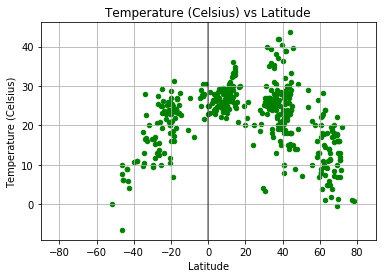

```python
# Temperature vs Latitude
selected_cities.plot(kind="scatter",x="Latitude",y="Temperature",grid=True,color="green")

set_plot_prop("Latitude",[-90,90],"Temperature (Celsius)")
plt.axvline(0, color='black',alpha=0.5)
plt.savefig("Temperature vs Latitude")
plt.show()
```

#### Humidity (%) vs. Latitude

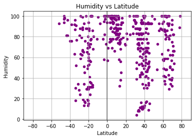

```python
# Humidity vs Latitude

selected_cities.plot(kind="scatter",x="Latitude",y="Humidity",grid=True,color="purple")

set_plot_prop("Latitude",[-90,90],"Humidity")
plt.axvline(0, color='black',alpha=0.5)
plt.savefig("Humidity vs Latitude")
plt.show()
```

#### Cloudiness (%) vs. Latitude

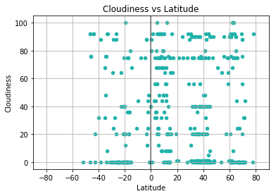

```python
# Cloudiness vs Latitude
selected_cities["Cloudiness"] = pd.to_numeric(selected_cities["Cloudiness"])
selected_cities.plot(kind="scatter",x="Latitude",y="Cloudiness",grid=True,color="lightseagreen")

set_plot_prop("Latitude",[-90,90],"Cloudiness")
plt.axvline(0, color='black',alpha=0.5)
plt.savefig("Cloudiness vs Latitude")
plt.show()
```

[figure not shown]

```python
# Wind speed vs Latitude
selected_cities["Wind speed"] = pd.to_numeric(selected_cities["Wind speed"])
selected_cities.plot(kind="scatter",x="Latitude",y="Wind speed",grid=True,color="darkorange")

set_plot_prop("Latitude",[-90,90],"Wind speed (mph)")
plt.axvline(0, color='black',alpha=0.5)
plt.savefig("Wind speed vs Latitude")
plt.show()
```

Your final notebook must:

- Randomly select at least 500 unique (non-repeat) cities based on latitude and longitude.
- Perform a weather check on each of the cities using a series of successive API calls.
- Include a print log of each city as it's being processed with the city number, city name, and requested URL.
- Save both a CSV of all data retrieved and png images for each scatter plot.

As final considerations:

- You must use the Matplotlib and Seaborn libraries.
- You must include a written description of three observable trends based on the data.
- You must use proper labeling of your plots, including aspects like: Plot Titles (with date of analysis) and Axes Labels.
- You must include an exported markdown version of your Notebook called README.md in your GitHub repository.
- See Example Solution for a reference on expected format.